# DATA 606 Data Project Proposal

Sung Lee

### Data Preparation

```r
# load data
library(tidyverse)
library(psych)
library(summarytools)
library(ggplot2)

licenses_df <- read_csv("https://raw.githubusercontent.com/logicalschema/Data606Project/master/License_Applications.csv.gz")

names(licenses_df)<-str_replace_all(names(licenses_df), c(" " = "_"))

head(licenses_df)
```

```
## # A tibble: 6 x 25
##   Application_ID License_Number License_Type Application_or_~ Business_Name
##   <chr>          <chr>          <chr>        <chr>            <chr>
## 1 1066-2017-RHIC 1294131-DCA    Business     Renewal          PEYKO TZENOV
## 2 1164-2019-RDPD 1472251-DCA    Business     Renewal          AMERICAN EAS~
## 3 33701-2016-RE~ 2025971-DCA    Business     Renewal          LUCAS ELECTR~
## 4 34278-2018-RE~ 2047043-DCA    Business     Renewal          ELITE WIRELE~
## 5 3891-2019-ALAU 2085269-DCA    Business     Application      A-LIN LAUNDR~
## 6 12418-2017-AE~ 2057790-DCA    Business     Application      RIDGE WIRELE~
## # ... with 20 more variables: Status <chr>, Start_Date <chr>, End_Date <chr>,
## #   Temp_Op_Letter_Issued <date>, Temp_Op_Letter_Expiration <chr>,
## #   License_Category <chr>, Application_Category <chr>, Building_Number <chr>,
## #   Street <chr>, Street_2 <chr>, Unit_Type <chr>, Unit <chr>,
## #   Description <chr>, City <chr>, State <chr>, Zip <chr>, Contact_Phone <chr>,
## #   Longitude <dbl>, Latitude <dbl>, Active_Vehicles <lgl>
```

```r
names(licenses_df)
```

```
##  [1] "Application_ID"            "License_Number"
##  [3] "License_Type"              "Application_or_Renewal"
##  [5] "Business_Name"             "Status"
##  [7] "Start_Date"                "End_Date"
##  [9] "Temp_Op_Letter_Issued"     "Temp_Op_Letter_Expiration"
## [11] "License_Category"          "Application_Category"
## [13] "Building_Number"           "Street"
## [15] "Street_2"                  "Unit_Type"
## [17] "Unit"                      "Description"
## [19] "City"                      "State"
## [21] "Zip"                       "Contact_Phone"
## [23] "Longitude"                 "Latitude"
## [25] "Active_Vehicles"
```

### Research question

**You should phrase your research question in a way that matches up with the scope of inference your dataset allows for.**

Do economic downturns impact the number of tobacco and liquor license applications in NYC?

### Cases

**What are the cases, and how many are there?**

There are 368,017 applications and renewals for NYC business licenses in varying license categories from 4/10/98 to 4/16/20.

### Data collection

**Describe the method of data collection.**

Data is collected by NYC and recorded on their OpenData platform: https://data.cityofnewyork.us/. This is the original page of the data: https://data.cityofnewyork.us/Business/License-Applications/ptev-4hud/data

### Type of study

**What type of study is this (observational/experiment)?**

This is an observational study.

### Data Source

**If you collected the data, state self-collected. If not, provide a citation/link.**

This is the link for the data: https://data.cityofnewyork.us/Business/License-Applications/ptev-4hud

Additional information about the data: https://data.cityofnewyork.us/api/views/ptev-4hud/files/e9ee6ec0-796d-4273-853f-0ccd05920c2f?download=true&filename=DCA%20License%20Applications%20Data%20Dictionary.pdf

### Dependent Variable

**What is the response variable? Is it quantitative or qualitative?**

The response variable is the *License Category* and it is qualitative.

### Independent Variable

**You should have two independent variables, one quantitative and one qualitative.**

The two independent variables are: *Start Date* (quantitative) and *Application or Renewal* (qualitative).

### Relevant summary statistics

**Provide summary statistics for each the variables. Also include appropriate visualizations related to your research question (e.g. scatter plot, boxplots, etc). This step requires the use of R, hence a code chunk is provided below. Insert more code chunks as needed.**

```r
dfSummary(licenses_df$License_Category)
```

```
## licenses_df$License_Category was converted to a data frame
```

```
## Data Frame Summary
## licenses_df
## Dimensions: 368017 x 1
## Duplicates: 367957
##
## ------------------------------------------------------------------------------------------------------------------------
## No   Variable            Stats / Values                   Freqs (% of Valid)   Graph                 Valid     Missing
## ---- ------------------- -------------------------------- -------------------- --------------------- --------- ---------
## 1    License_Category    1. Amusement Arcade                  81 ( 0.0%)                             368017    0
##      [factor]            2. Amusement Device Permanen        793 ( 0.2%)                             (100%)    (0%)
##                          3. Amusement Device Portable       3849 ( 1.0%)
##                          4. Amusement Device Temporar        497 ( 0.1%)
##                          5. Auction House Premises           140 ( 0.0%)
##                          6. Auctioneer                      1138 ( 0.3%)
##                          7. Bingo Game Operator               79 ( 0.0%)
##                          8. Booting Company                   15 ( 0.0%)
##                          9. Cabaret                          298 ( 0.1%)
##                          10. Car Wash                        364 ( 0.1%)
##                          [ 50 others ]                    360763 (98.0%)       IIIIIIIIIIIIIIIIIII
## ------------------------------------------------------------------------------------------------------------------------
```

```r
dfSummary(licenses_df$Start_Date)
```

```
## licenses_df$Start_Date was converted to a data frame
```

```
## Data Frame Summary
## licenses_df
## Dimensions: 368017 x 1
## Duplicates: 362564
##
## ----------------------------------------------------------------------------------------------------
## No   Variable      Stats / Values     Freqs (% of Valid)   Graph                 Valid     Missing
## ---- ------------- ------------------ -------------------- --------------------- --------- ---------
## 1    Start_Date    1. 01/01/2014           2 ( 0.0%)                             368017    0
##      [factor]      2. 01/01/2015           3 ( 0.0%)                             (100%)    (0%)
##                    3. 01/01/2017          11 ( 0.0%)
##                    4. 01/01/2018           9 ( 0.0%)
##                    5. 01/01/2019           9 ( 0.0%)
##                    6. 01/01/2020           1 ( 0.0%)
##                    7. 01/02/2001         260 ( 0.1%)
##                    8. 01/02/2002          23 ( 0.0%)
##                    9. 01/02/2003          13 ( 0.0%)
##                    10. 01/02/2004         14 ( 0.0%)
##                    [ 5443 others ]    367672 (99.9%)       IIIIIIIIIIIIIIIIIII
## ----------------------------------------------------------------------------------------------------
```

```r
dfSummary(licenses_df$Application_or_Renewal)
```

```
## licenses_df$Application_or_Renewal was converted to a data frame
```

```
## Data Frame Summary
## licenses_df
## Dimensions: 368017 x 1
## Duplicates: 368015
##
## ---------------------------------------------------------------------------------------------------------
## No   Variable                  Stats / Values     Freqs (% of Valid)   Graph          Valid     Missing
## ---- ------------------------- ------------------ -------------------- -------------- --------- ---------
## 1    Application_or_Renewal    1. Application     134978 (36.7%)       IIIIIII        368017    0
##      [factor]                  2. Renewal         233039 (63.3%)       IIIIIIIIIIII   (100%)    (0%)
## ---------------------------------------------------------------------------------------------------------
```

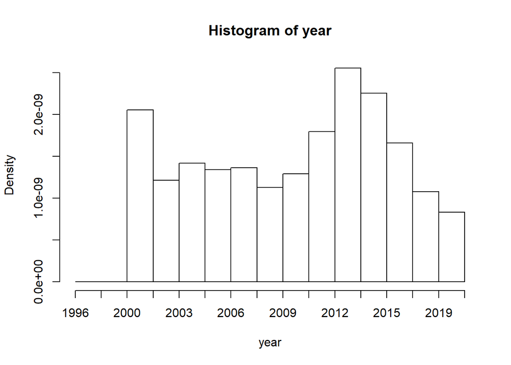

```r
tobacco <- filter(licenses_df, License_Category == "Tobacco Retail Dealer")


formatDate <- strptime(as.character(tobacco$Start_Date),format="%m/%d/%Y")
hist(formatDate,breaks=10,xlab="year")
```